# HW 1: Анализ деятельности авиалиний и аэропортов

Петрова Екатерина, enpetrova_3

## Задача

на основе данных (и выданных вопросов) постараться выяснить:

- какие проблемы есть в авиаперевозках
- какие улучшения можно предложить на основе выводов по данным

#### Загрузка данных и преобразование

Все нужные данные для вопросов в нужных форматах

### Вопросы

#### Вопрос 1

**Вопрос:** -Люди из каких стран выше всего оценили свои перелеты?

**Данные:** для ответа на вопрос нужна таблица airline, так как авиалиния отвечает за самолет, все удобства, расписание, и его общий рейтинг показывает отношение ко всему перелету

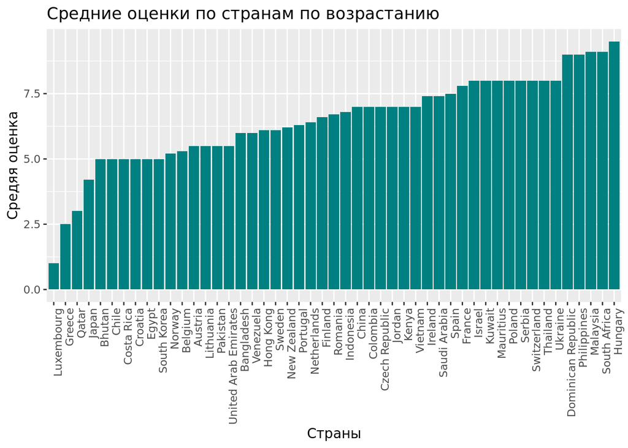

**Ответ:** Из данного графика видно, что люди из Венгрии оценили свои перелеты выше всех, когда как люди из Люксембурга оставили отзывы с наименьшим показателем. В определенный период люди из 49 стран в среднем хорошо отозвались о своем перелете. Иногда не хватало данных, чтобы сформулировать точнее мнение о качестве совершенных перелетов.

**Вывод:** Страны, выше всех оценившие перелёты, достаточно разнообразны по местоположению и экономическому развитию, из-за чего достаточно сложно найти в них общие черты, помогающие сделать достоверный вывод. Поэтому вдальнейшем было бы интересно вычислить среднюю оценку авиаперелетов по всему миру в определенный отрезок времени, а также брать информацию о причине поездки и взять во внимание класс перелета, чтобы посмотреть на процентное соотношение людей из этих стран с наивысшими оценками. Также можно изучить, как много людей из каждой страны летают на самолётах и имеют больше опыта для сравнения и оценки сервисов авиалиний.

#### Вопрос 2

**Вопрос:** -Отличается ли использование слов "not good", "bad", "awful" в отзывах на авиалинии у путешественников из разных классов (cabin_flown)?

**Данные:** нужна таблица airline, т.к. производится анализ отзывов на авиалинии

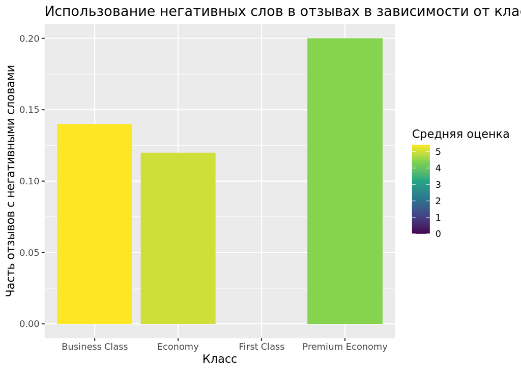

**Вывод:** Предположительно, Премиуим Эконом класс имеет больше всех отрицательных слов, из-за того, что это люди, которые имеют недостаточно денег для Бизнес класса, но всё равно доплачивают дополнительные услуги и имеют ожидания выше. Так что возможно можно было бы улучшить качество Премиум Эконом класса в сравнении с Экономом. Так же использование слов not good, bad, awful не говорит об оценке в целом, т.к. люди могут сделать акцент на вещи, которая им не понравилось, но в целом иметь хорошее представление о полёте. Так что лучше судить о полёте через непосредственную оценку, которую они ставят за неё и среди уже низких искать негативные слова, чтобы понять, что именно им не понравилось. Так же можно взять во внимание тип пассажира и посмотреть их соотношение в каждом классе.

**Вопрос:** -Какие лаунж-зоны оценены по качеству wi-fi выше, чем аэропорты, в которых они расположены?

**Данные:** для ответа на вопрос нужны таблицы lounge и airport

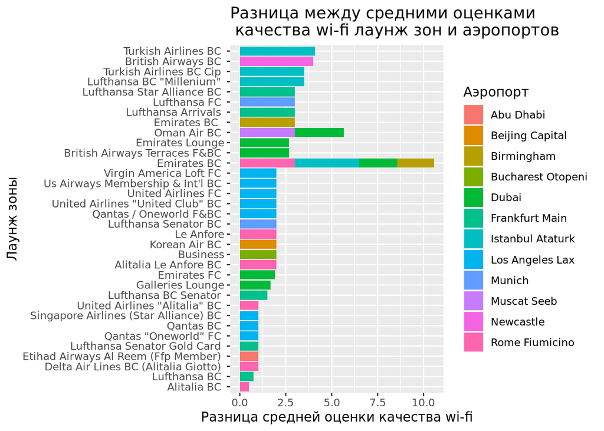

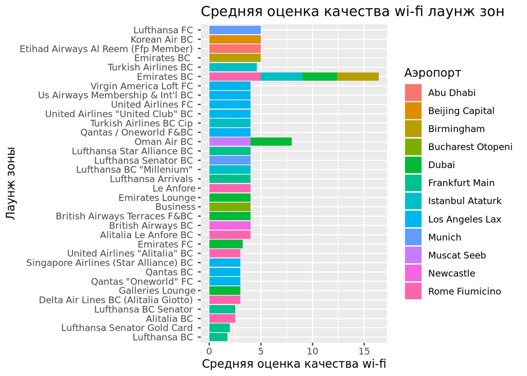

**Ответ:** Как представлено на графике есть 38 лаунж-зон, которые оценены выше по качеству вайфая, чем аэропорты, в которых они находятся. В сравнении с аэропортами, в которых расположены лаунж зоны, наилучшими по качеству wi-fi являются Turkish Airlines Business Class, British Airways Business Class и Emirates Business Class.

### Дэшборд

Полученные выводы обобщены в виде дэшборда со следующими элементами

**Элемент 1:** - вид: график - ответ на вопрос: 3 - обоснование: для вопроса “какие лаунж зоны оценены по качеству wi-fi выше, чем аэропорты, в которых они расположены” подходит перевернутая столбчатая диаграмма, т.к. она хорошо отображает насколько качество wi-fi у лаунж зон лучше, визуализирует какие лаунжи из одного аэропорта оценены выше относительно друг друга и насколько, а также по цветам диаграммы можно отследить насколько часто появляются определённые аэропорты.

**Элемент 2:** - вид: числа - ответ на вопрос: 3 - обоснование: так как лаунж зон достаточно много, их количество отображается отдельно для лучшего понимания.

**Элемент 3:** - вид: числа - ответ на вопрос: 1 - обоснование: так как можно было вставить в дэшборд только два графика/таблицы, и страны никак нельзя разделить по группам, на этот вопрос решено было выбрать самую высокую оценку и её страну.

**Элемент 4:** - вид: график - ответ на вопрос: 2 - обоснование: даётся сравнение по соотношению количества людей, использовавших негативные слова, разных классов и их выделена средняя оценка, а на данный вопрос невозможно ответить одним числом или фразой.

### Общие выводы

Предоставленные данные хороши только для поверхностного анализа деятельности авиалиний и аэропортов. Также от формулировки вопроса зависело очень много факторов анализа, так что хотелось бы иметь конечную цель, для который его хотят провести. Тем не менее, цель я считаю выполненной, и на качество авиаперевозок можно сделать краткий обзор .